# Business Problem Statement:

## POST-BUCKETING VISUALIZATIONS FOR INFERENCES

### SCR Vs Age-Category Vs Target

AGE Intervals & Ranking

- (20.9, 30.0] ----> 1
- (30.0, 38.0] ----> 2
- (38.0, 46.0] ----> 3
- (46.0, 55.0] ----> 4

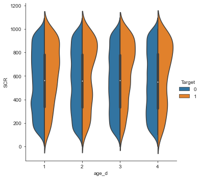

```python
sns.catplot(x="age_d", y="SCR", hue = "Target",data=data1, kind = "violin", split = True)
plt.show()
```

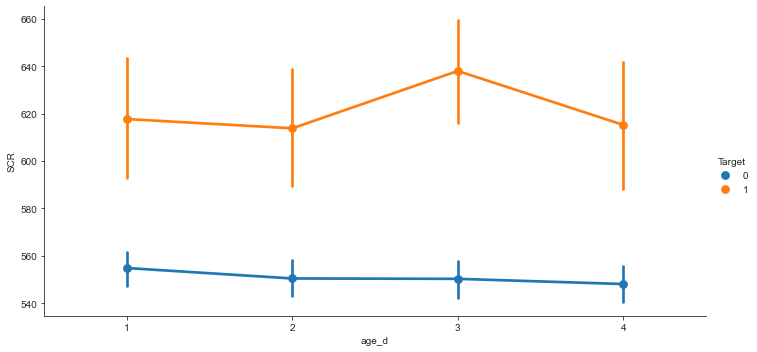

```python
sns.catplot(x="age_d", y="SCR", hue = "Target",data=data1, aspect=2.0, kind = "point")
plt.show()
```

##### Inferences:

- The `Age groups` `(20.9-30] years` and `(38-46] years` tend to showwcase higher `SCR` values hence more interest towards opting for lonans. However, the age groups (30-38] and (46.0-55) showcase least interest in opting for loans.

### SCR Vs Age-Category Vs Target

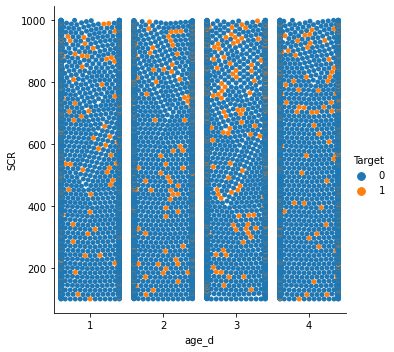

```python
sns.catplot(x="age_d", y="SCR", hue = "Target",data=data1, kind = "swarm")
plt.show()
```

```python
sns.set_style('ticks')
```

## BUCKETING SCR & HOLDING PERIODS

```python
data1['SCRb'] = pd.qcut(data['SCR'], q=5)
```

```python
data1.SCRb.value_counts()
```

```
(99.999, 288.0]    3987
(468.0, 651.0]     3964
(826.0, 999.0]     3956
(651.0, 826.0]     3952
(288.0, 468.0]     3945
Name: SCRb, dtype: int64
```

```python
data1['HPB'] = pd.qcut(data['Holding_Period'], q=4)
```

```python
data1.HPB.value_counts()
```

```
(0.999, 8.0]    5519
(16.0, 23.0]    4998
(8.0, 16.0]     4791
(23.0, 31.0]    4496
Name: HPB, dtype: int64
```

```python
data1.head()
```

|  | Target | Age | Balance | No_OF_CR_TXNS | SCR | Holding_Period | Gender_F | Gender_M | Occupation_PROF | Occupation_SAL | Occupation_SELF-EMP | Occupation_SENP | Ageb_(20.999, 30.0] | Ageb_(30.0, 38.0] | Ageb_(38.0, 46.0] | Ageb_(46.0, 55.0] | age_d | SCRb | HPB |
| --- | --- | --- | --- | --- | --- | --- | --- | --- | --- | --- | --- | --- | --- | --- | --- | --- | --- | --- | --- |
| 0 | 0 | 41 | 91519 | 38 | 926 | 15 | 0 | 1 | 0 | 0 | 1 | 0 | 0 | 0 | 1 | 0 | 3 | (826.0, 999.0] | (8.0, 16.0] |
| 1 | 0 | 52 | 117288 | 17 | 768 | 13 | 0 | 1 | 0 | 1 | 0 | 0 | 0 | 0 | 0 | 1 | 4 | (651.0, 826.0] | (8.0, 16.0] |
| 2 | 0 | 31 | 259827 | 8 | 816 | 5 | 1 | 0 | 0 | 0 | 0 | 1 | 0 | 1 | 0 | 0 | 2 | (651.0, 826.0] | (0.999, 8.0] |
| 3 | 0 | 45 | 26677 | 14 | 353 | 18 | 1 | 0 | 1 | 0 | 0 | 0 | 0 | 0 | 1 | 0 | 3 | (288.0, 468.0] | (16.0, 23.0] |
| 4 | 0 | 39 | 43440 | 1 | 751 | 31 | 1 | 0 | 0 | 0 | 0 | 1 | 0 | 0 | 1 | 0 | 3 | (651.0, 826.0] | (23.0, 31.0] |

### SCR-Bucketed Vs Age-Category Vs Target

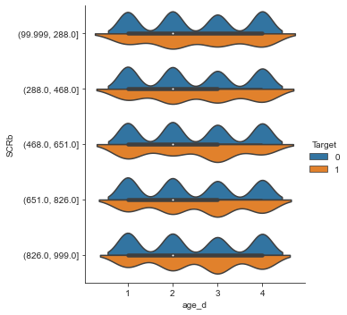

```python
sns.catplot(x="age_d", y="SCRb", hue = "Target",data=data1, kind = "violin", split = True)
plt.show()
```

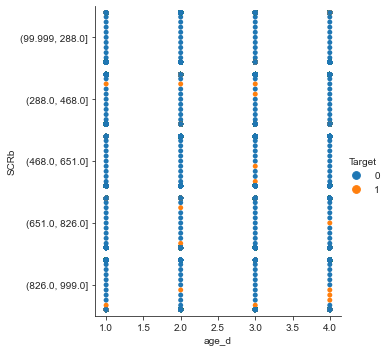

```python
sns.catplot(x="age_d", y="SCRb", hue = "Target",data=data1, kind = "swarm")
plt.show()
```

##### Inferences:

- People in the `Age Group` `(46.0, 55.0]` years tend to have higher `SCR` score i.e. 826 to 1000 points and opt for loans as compared to `(30.0, 38.0]` years who stand at the second position for higher `SCR` values i.e. 650 to 830 points.
- People in the `Age Group` `(38.0, 46.0]` years tend to have `SCR` values between 400 to 650 points.

### Holding Period Bucketed Vs Age-Category Vs Target

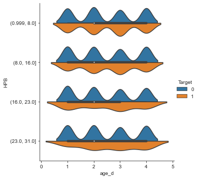

```python
sns.catplot(x="age_d", y="HPB", hue = "Target",data=data1, kind = "violin", split = True)
plt.show()
```

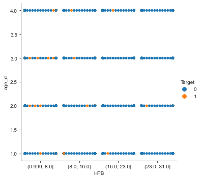

```python
sns.catplot(x="HPB", y="age_d", hue = "Target",data=data1, kind = "swarm")
plt.show()
```

##### Inferences:

- Higher the `Holding Period` more stable is the money in the person's account.
- `Holding Period` of 23-31 weeks tends to be uniform across all the `Age Groups`
- `Holding Period` between 1-8 weeks tends to lie in the `Age Groups` = 2 and 3 i.e. (30.0, 38.0] and (38.0, 46.0]

### Pair-Plot on Bucketed Data

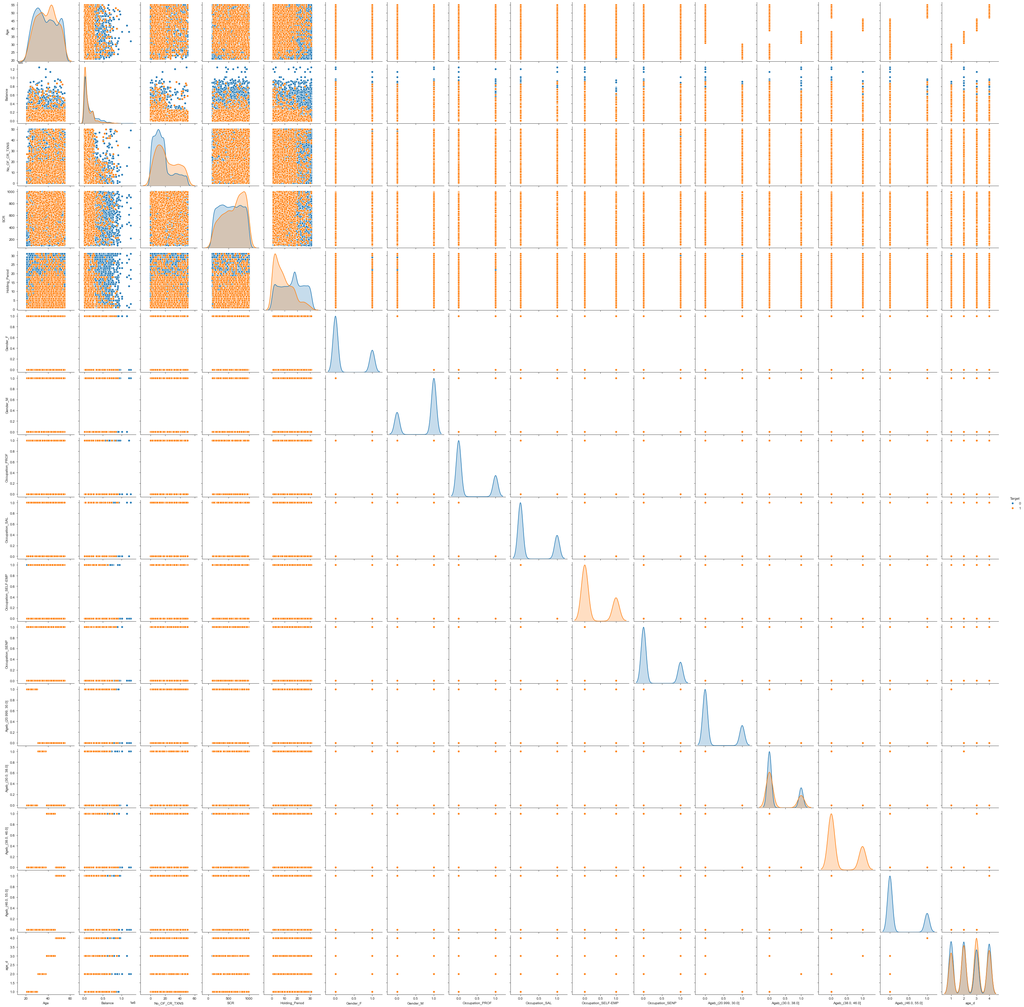

```python
sns.pairplot(data1, hue = 'Target')
plt.show()
```

##### Inferences from Pair-Plot:

- People who tend to opt for loan have less `BALANCE` w.r.t people not buying loan.
- People having higher `BALANCE` tend to be in between 35-50 years of `AGE`.
- People having less `BALANCE` tend to show more interest towards loans i.e. higher `SCR` values.
- People having less `BALANCE` tend to have higher `No of Credit transactions` opt for loans.
- People having less `BALANCE` have higher `HOLDING PERIOD` who opt for loans.

### ----------------------------------------------------Start of Black Box Models Exploration------------------------------------------------

## SHAP - BlackBox Model

```python
# import shap
```

```python
# X_train_summary = shap.kmeans(X_train_orig, 10)
```

```python
# explainerKNN = shap.KernelExplainer(clf_KNN0.predict,X_train_summary)
```

```python
# shap_values_KNN_test = explainerKNN.shap_values(X_test_orig)
```

```python
# shap.initjs()
# shap.force_plot(explainerKNN.expected_value, shap_values_KNN_test[:1000,:], X_test_orig.iloc[:1000,:])
```

## LIME- BlackBox Model

```python
# import lime
# import lime.lime_tabular
```

```python
# lgb_params = {
#   'task': 'train',
#     'boosting_type': 'goss',
#     'objective': 'binary',
#     'metric':'binary_logloss',
#     'metric': {'l2', 'auc'},
#     'num_leaves': 50,
#     'learning_rate': 0.1,
#     'feature_fraction': 0.8,
#     'bagging_fraction': 0.8,
#     'verbose': None,
#     'num_iteration':100,
#     'num_threads':7,
#     'max_depth':12,
#     'min_data_in_leaf':100,
#     'alpha':0.5}
```

```python
# import warnings
# from lime import submodular_pick
# import lightgbm as lgb

# lgb_train = lgb.Dataset(X_train_orig, y_train_orig)
# lgb_eval = lgb.Dataset(X_test_orig, y_test_orig)

# model = lgb.train(lgb_params,lgb_train,num_boost_round=20,valid_sets=lgb_eval,early_stopping_rounds=5)
# lime.lime_tabular.LimeTabularExplainer(data[model.feature_name()].astype(int).values,
# mode='classification',training_labels=data3['Target'],feature_names=model.feature_name())
# # Remember to convert the dataframe to matrix values
# # SP-LIME returns exaplanations on a sample set to provide a non redundant global decision boundary of original model
# sp_obj = submodular_pick.SubmodularPick(explainer,data3[model.feature_name()].values, \
# prob, num_features=5,num_exps_desired=10)

# [exp.as_pyplot_figure(label=1) for exp in sp_obj.sp_explanations]
```

## CatBoost Classifier

```python
# from catboost import CatBoostClassifier
# model = CatBoostClassifier(random_seed=42)
```

```python
# cate_features_index = np.where(data.dtypes != float)[0]
```

```python
# X_over_train
```

```python
# model.fit(X_under_train,y_under_train,cat_features=cate_features_index)
```

```python
# test = pd.read_csv("test_data.csv")
# pred = model.predict(test)
```

```python
# from sklearn.metrics import confusion_matrix
```

```python
# confusion_matrix(y_test_orig, pred)
```

### ----------------------------------------------------End of Black Box Models Exploration------------------------------------------------

## Model Evaluation Matrix - Which Models to be Considered?

```python
model_eval = {'Good Fit Percent%': ['10.9','9.84','19.6','17.2','8.6','18.4','11.4','25.0','25.0','16.4','20.8','17.2'],
        'Comments': ['Not Considering','Not Considering','Not Considering','Not Considering','Not Considering','Not Considering',
                     'Not Considering','Considering','Considering','Not Considering','Considering','Not Considering',]
        }

df = pd.DataFrame(model_eval, columns = ['Good Fit Percent%','Comments'], index=['DecisionTreeClassifier - Original Data','DecisionTreeClassifier - UnderSampled Data','DecisionTreeClassifier - OverSampled Data',
                                                                           'KNN Classifier - Original Data','KNN Classifier - Undersampled Data','Random Forest Classifier - Original Data','RandomForest Classifier - Undersampled Data',
                                                                           'RandomForest Classifier - Oversampled Data','Logistic Regression - Original Data','Logistic Regression - Undersampled Data',
                                                                          'Logistic Regression - Oversampled Data','KNN Classifier - Oversampled Data'])

print (df)
```

```
                                            Good Fit Percent%         Comments
DecisionTreeClassifier - Original Data                   10.9  Not Considering
DecisionTreeClassifier - UnderSampled Data               9.84  Not Considering
DecisionTreeClassifier - OverSampled Data                19.6  Not Considering
KNN Classifier - Original Data                           17.2  Not Considering
KNN Classifier - Undersampled Data                        8.6  Not Considering
Random Forest Classifier - Original Data                 18.4  Not Considering
RandomForest Classifier - Undersampled Data              11.4  Not Considering
RandomForest Classifier - Oversampled Data               25.0      Considering
Logistic Regression - Original Data                      25.0      Considering
Logistic Regression - Undersampled Data                  16.4  Not Considering
Logistic Regression - Oversampled Data                   20.8      Considering
KNN Classifier - Oversampled Data                        17.2  Not Considering
```

### ------------------------------------------------------------End of Capstone---------------------------------------------------------------------